# Predicting CLV of banking customers using ML

Install and load in random forest and xg boost packages

```r
library(randomForest)
library(xgboost)
library(caret)
```

Read in bank churn data

```r
bank = read.csv("bank_churn.csv")
head(bank)
```

|  | Churned | Customer_Age | Gender | Dependent_count | Education_Level | Marital_Status | Income_Category | Card_Category | Months_on_book | Months_Inactive_12_mon | Contacts_Count_12_mon | Credit_Limit | Total_Revolving_Bal | Total_Amt_Chng_Q4_Q1 | Total_Trans_Amt | Total_Trans_Ct | Total_Ct_Chng_Q4_Q1 | Avg_Utilization_Ratio |
| --- | --- | --- | --- | --- | --- | --- | --- | --- | --- | --- | --- | --- | --- | --- | --- | --- | --- | --- |
| 1 | 0 | 45 | M | 3 | High School | Married | $60K - $80K | Blue | 39 | 1 | 3 | 12691 | 777 | 1.335 | 1144 | 42 | 1.625 | 0.061 |
| 2 | 0 | 49 | F | 5 | Graduate | Single | Less than $40K | Blue | 44 | 1 | 2 | 8256 | 864 | 1.541 | 1291 | 33 | 3.714 | 0.105 |
| 3 | 1 | 51 | M | 3 | Graduate | Married | $80K - $120K | Blue | 36 | 1 | 0 | 3418 | 0 | 2.594 | 1887 | 20 | 2.333 | 0.000 |
| 4 | 0 | 40 | F | 4 | High School | Unknown | Less than $40K | Blue | 34 | 4 | 1 | 3313 | 2517 | 1.405 | 1171 | 20 | 2.333 | 0.760 |
| 5 | 0 | 40 | M | 3 | Uneducated | Married | $60K - $80K | Blue | 21 | 1 | 0 | 4716 | 0 | 2.175 | 816 | 28 | 2.500 | 0.000 |
| 6 | 1 | 44 | M | 2 | Graduate | Married | $40K - $60K | Blue | 36 | 1 | 2 | 4010 | 1247 | 1.376 | 1088 | 24 | 0.846 | 0.311 |

Take a sample of that dataset

```r
short_data = bank[1:100,1:4]
summary(short_data)
```

```
    Churned      Customer_Age      Gender          Dependent_count
 Min.   :0.00   Min.   :32.00   Length:100         Min.   :0.0
 1st Qu.:0.00   1st Qu.:44.00   Class :character   1st Qu.:1.0
 Median :0.00   Median :49.00   Mode  :character   Median :2.0
 Mean   :0.15   Mean   :49.62                      Mean   :2.4
 3rd Qu.:0.00   3rd Qu.:54.25                      3rd Qu.:3.0
 Max.   :1.00   Max.   :66.00                      Max.   :5.0
```

## Random Forest

For a random forest for classification, the outcome has to be a factor. That’s why I use factor(Churned).

```r
rf = randomForest(factor(Churned) ~ . , data = short_data, importance = TRUE)
rf
```

```
Call:
 randomForest(formula = factor(Churned) ~ ., data = short_data,      importance = TRUE)
               Type of random forest: classification
                     Number of trees: 500
No. of variables tried at each split: 1

        OOB estimate of  error rate: 13%
Confusion matrix:
   0 1 class.error
0 85 0   0.0000000
1 13 2   0.8666667
```

We can look at the importance

```r
rf$importance
```

```
                          0          1 MeanDecreaseAccuracy MeanDecreaseGini
Customer_Age    0.005180544 0.03067143          0.008828872        4.8948987
Gender          0.003293931 0.04137063          0.008956666        0.9957853
Dependent_count 0.005316895 0.04361429          0.010663655        3.1583456
```

Summarize the Dependent_count

```r
summary(short_data$Dependent_count)
```

```
   Min. 1st Qu.  Median    Mean 3rd Qu.    Max.
    0.0     1.0     2.0     2.4     3.0     5.0
```

Let’s predict with some new data:

```r
newdata = rbind(
  data.frame(
    Customer_Age = 20,
    Gender = "M",
    Dependent_count = 0
  ),
  data.frame(
    Customer_Age = 35,
    Gender = "F",
    Dependent_count = 1
  )
)

predict(rf, newdata, type = "response")
```

```
1 2
0 0
Levels: 0 1
```

Notice this difference from logistic regression: type = “response” gives you the predicted outcome, not a probability. To get a probability, we do:

```r
predict(rf, newdata, type = "prob")
```

```
      0     1
1 0.928 0.072
2 0.950 0.050
attr(,"class")
[1] "matrix" "array"  "votes"
```

## XGBoost

Formatting the data for XGBoost is a bit more tedious…

```r
y = short_data$Churned == 1
x = model.matrix(~ 0 + . - Churned, data = short_data)

xgb = xgboost(data = x, label = y, nrounds = 500, objective = "binary:logistic")
xgb
```

```
##### xgb.Booster
raw: 488 Kb
call:
  xgb.train(params = params, data = dtrain, nrounds = nrounds,
    watchlist = watchlist, verbose = verbose, print_every_n = print_every_n,
    early_stopping_rounds = early_stopping_rounds, maximize = maximize,
    save_period = save_period, save_name = save_name, xgb_model = xgb_model,
    callbacks = callbacks, objective = "binary:logistic")
params (as set within xgb.train):
  objective = "binary:logistic", validate_parameters = "TRUE"
xgb.attributes:
  niter
callbacks:
  cb.print.evaluation(period = print_every_n)
  cb.evaluation.log()
# of features: 4
niter: 500
nfeatures : 4
evaluation_log:
```

| iter | train_logloss |
| --- | --- |
| 1 | 0.5645656 |
| 2 | 0.4935972 |
| 3 | 0.4508962 |
| 4 | 0.4253231 |
| 5 | 0.4034136 |
| 6 | 0.3817070 |
| 7 | 0.3656190 |
| 8 | 0.3552860 |
| 9 | 0.3370054 |
| 10 | 0.3314638 |

[output cut: 490 more lines]

Making predictions with new data is again a little tedious…

```r
X_new = model.matrix(~ 0 + ., data = newdata)
X_new = X_new[,colnames(c("Customer_Age", "Gender", "Dependent_count"))]
```

XGBoost only returns predicted probabilities:

```r
predict(xgb, X_new)
```

```
[1] 0.01519531 0.01519531
```

## Predicting Churn

Split the data into in-sample and out-of-sample data

```r
train_rows = createDataPartition(y = 1:nrow(bank), p = 0.8, list = FALSE)
train = bank[train_rows, ]
test = bank[-train_rows, ]
```

Step 1: Run each of the competing models using the training data

```r
lr_churn = glm(Churned == 1 ~ ., data = train, family = binomial)
rf_churn = randomForest(factor(Churned == 1) ~ ., data = train)
```

XGBoost is a little more complicated: For XGBoost, we can’t use a data.frame. To convert the data.frame into a numeric matrix, with the correct dummy variables, we do:

```r
xgb_y_churn_train = train[,"Churned"]
xgb_x_churn_train = model.matrix(~ 0 + . - Churned, data = train)
xgb_x_churn_test = model.matrix(~ 0 + . - Churned, data = test)
```

Then to run the model we call:

```r
xgb_churn = xgboost(
  data = xgb_x_churn_train,
  label = xgb_y_churn_train,
  objective = "binary:logistic",
  nrounds = 50
)
```

Step 2: Make predictions in the holdout data

```r
lr_churn_prob = predict(lr_churn, newdata = test, type = "response")
lr_churn_pred = lr_churn_prob > 0.5

rf_churn_prob = predict(rf_churn, newdata = test, type = "prob")[,"TRUE"]
rf_churn_pred = rf_churn_prob > 0.5

xgb_churn_prob = predict(xgb_churn, newdata = xgb_x_churn_test)
xgb_churn_pred = xgb_churn_prob > 0.5
```

Step 3: Use the confusionMatrix() function from the caret package

```r
confusionMatrix(factor(lr_churn_pred), factor((test$Churned == 1)))
```

```
Confusion Matrix and Statistics

          Reference
Prediction FALSE TRUE
     FALSE  1478  310
     TRUE     68  168

               Accuracy : 0.8132
                 95% CI : (0.7956, 0.83)
    No Information Rate : 0.7638
    P-Value [Acc > NIR] : 4.594e-08

                  Kappa : 0.3726

 Mcnemar's Test P-Value : < 2.2e-16

            Sensitivity : 0.9560
            Specificity : 0.3515
         Pos Pred Value : 0.8266
         Neg Pred Value : 0.7119
             Prevalence : 0.7638
         Detection Rate : 0.7302
   Detection Prevalence : 0.8834
      Balanced Accuracy : 0.6537

       'Positive' Class : FALSE
```

```r
confusionMatrix(factor(rf_churn_pred), factor((test$Churned == 1)))
```

```
Confusion Matrix and Statistics

          Reference
Prediction FALSE TRUE
     FALSE  1512  219
     TRUE     34  259

               Accuracy : 0.875
                 95% CI : (0.8598, 0.8891)
    No Information Rate : 0.7638
    P-Value [Acc > NIR] : < 2.2e-16

                  Kappa : 0.6001

 Mcnemar's Test P-Value : < 2.2e-16

            Sensitivity : 0.9780
            Specificity : 0.5418
         Pos Pred Value : 0.8735
         Neg Pred Value : 0.8840
             Prevalence : 0.7638
         Detection Rate : 0.7470
   Detection Prevalence : 0.8552
      Balanced Accuracy : 0.7599

       'Positive' Class : FALSE
```

```r
confusionMatrix(factor(xgb_churn_pred), factor((test$Churned == 1)))
```

```
Confusion Matrix and Statistics

          Reference
Prediction FALSE TRUE
     FALSE  1500  220
     TRUE     46  258

               Accuracy : 0.8686
                 95% CI : (0.8531, 0.883)
    No Information Rate : 0.7638
    P-Value [Acc > NIR] : < 2.2e-16

                  Kappa : 0.5833

 Mcnemar's Test P-Value : < 2.2e-16

            Sensitivity : 0.9702
            Specificity : 0.5397
         Pos Pred Value : 0.8721
         Neg Pred Value : 0.8487
             Prevalence : 0.7638
         Detection Rate : 0.7411
   Detection Prevalence : 0.8498
      Balanced Accuracy : 0.7550

       'Positive' Class : FALSE
```

## Computing CLV

For margin, assume that Blue = 5, Silver = 10, Platinum = 15. And assume that there is also some return on the revolving balance (1.5%)

```r
base_fee = ifelse(test$Card_Category == "Blue", 5,ifelse(test$Card_Category == "Silver", 10, 15))
margin = base_fee + 0.015*test$Total_Revolving_Bal
```

Retention rate

```r
r_lr = 1 - lr_churn_prob
r_rf = 1 - rf_churn_prob
r_xgb = 1 - xgb_churn_prob
```

Now, let’s plug into the CLV formula, assuming a monthly interest rate of 0.007:

```r
clv_lr = margin * (r_lr / (1 + 0.007 - r_lr))
clv_rf = margin * (r_rf / (1 + 0.007 - r_rf))
clv_xgb = margin * (r_xgb / (1 + 0.007 - r_xgb))
```

How do the models match up on CLV?

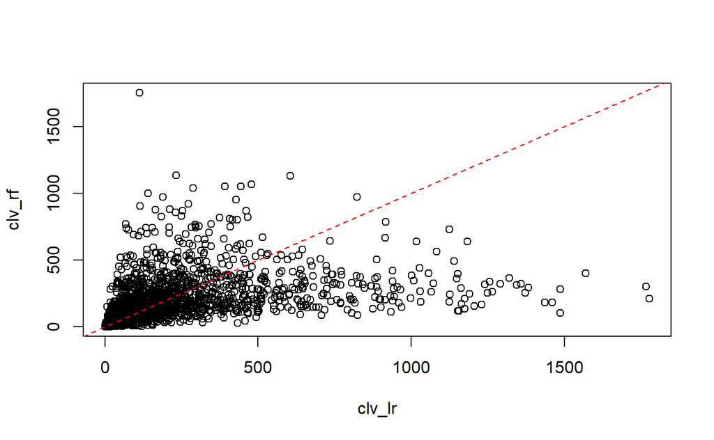

```r
plot(clv_lr, clv_rf)
abline(0, 1, col = "red", lty = 2)
```

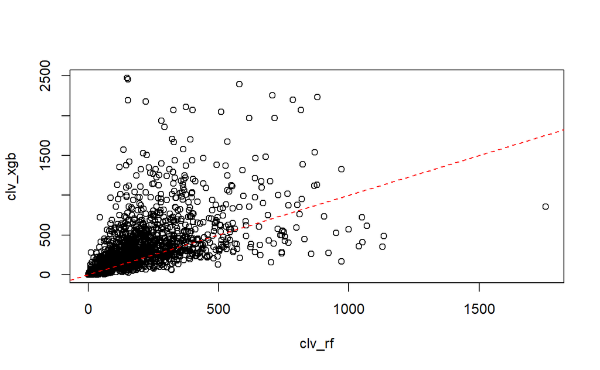

```r
plot(clv_rf, clv_xgb)
abline(0, 1, col = "red", lty = 2)
```

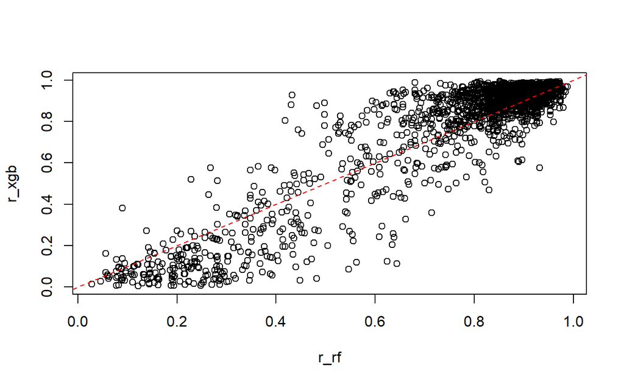

```r
plot(r_rf, r_xgb)
abline(0, 1, col = "red", lty = 2)
```